# Practical Machine Learning - Prediction Assignment

Szu-Fu Chao

6/7/2020

#### [Data]

The train data are available here:  
https://d396qusza40orc.cloudfront.net/predmachlearn/pml-training.csv

The test data are available here:  
https://d396qusza40orc.cloudfront.net/predmachlearn/pml-testing.csv

More information regarding the data background are available here:  
http://web.archive.org/web/20161224072740/http:/groupware.les.inf.puc-rio.br/har

```r
library(tidyverse)
library(naniar)
library(caret)
```

### **Goal**

The goal of the assignment is to use the measurements collected from the accelerometers to predict how well participants perform the weight lifting excecise.

### **Data Exploring and Preprocessing**

```r
train <- read.csv("pml-training.csv")
dim(train)
```

```
## [1] 19622   160
```

```r
set.seed(100)
inTrain <- createDataPartition(train$classe, p = 0.75, list = F)
training <- train[inTrain, ]
testing <- train[-inTrain, ]
dim(training)
```

```
## [1] 14718   160
```

```r
dim(testing)
```

```
## [1] 4904  160
```

There were a total of 160 variables and 19,622 observations in the train data. We first split the data into two subsets: training set (160 variables and 14,718 obs) and testing set (160 variables and 4,904 obs). We wanted to use the training set to train our predictive model, and then apply the model to the testing set.

```r
# drop the first 7 non-critical variables from both the training and testing sets
training <- training[-c(1:7)]
testing <- testing[-c(1:7)]

# make "classe" as factor in both the training set and testing sets
training$classe <- as.factor(training$classe)
testing$classe <- as.factor(testing$classe)

# recode undesired "#DIV/0!" to NA in both the training set and testing sets
training[training =="#DIV/0!"] <- NA
testing[testing =="#DIV/0!"] <- NA

# make all predictors as numeric in both the training set and testing sets
for (i in 1:152) {if (class(training[,i])=="character") {training[,i] <- as.numeric(training[,i])}}
for (i in 1:152) {if (class(testing[,i])=="character") {testing[,i] <- as.numeric(testing[,i])}}
```

After some minor but necessary modifications, we further explored the missing information since prediction algorithm was not built to handle missing in most cases.

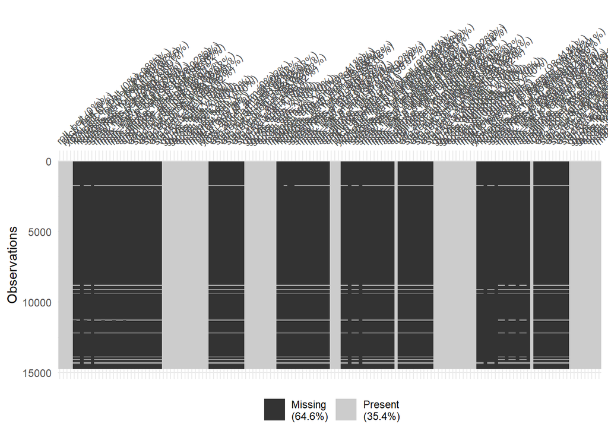

```r
# examine missing
vis_miss(training[-153], warn_large_data = F) # missing pattern
```

The plot above provided a visualization of the amount of missing data. It showed that the variables with missing all had extremely high missing rate (close to all missing).

```r
# identify variables with at least 95% missing rate
toExclude <- names(training)[-153][sapply(names(training)[-153], function(x) sum(is.na(training[x]))/nrow(training)>0.95)]

# drop the variables with severe missing
training <- training[!names(training) %in% toExclude]
testing <- testing[!names(testing) %in% toExclude]

# use nearZeroVar to further check if remaining predictors have near zero variance
length(nearZeroVar(training[-153]))
```

```
## [1] 0
```

```r
dim(training)
```

```
## [1] 14718    53
```

```r
dim(testing)
```

```
## [1] 4904   53
```

Given the circumstance, it might not be appropriate to use imputation to recover data therefore these variables were dropped. For the remaining variables, nearZeroVar function was used to detect predictors with near zero variance. None was identified. As a result, a total of 53 variables (52 predictors and 1 outcome variable) were included for modeling.

### **Model Training**

Tree-based algorithms - “Random Forest” and “GBM” - were used to train the model so that we didn’t have to worry about the underlying assumption regarding a certain data distribution which a model-based algorithm would need. The two methods are widely used and often achieve good performance in prediction.

#### *Random Forest*

```r
set.seed(201)
start_time <- Sys.time() # the begining of model training
mod_rf <- train(classe~., data=training, method="rf", trControl=trainControl(method = "cv"), number=3)
end_time <- Sys.time() # the end of model training
end_time - start_time # total processing time
```

```
## Time difference of 23.57051 mins
```

```r
confusionMatrix(predict(mod_rf, testing), testing$classe)
```

```
## Confusion Matrix and Statistics
##
##           Reference
## Prediction    A    B    C    D    E
##          A 1393    2    0    0    0
##          B    2  943    5    0    0
##          C    0    4  850   16    2
##          D    0    0    0  788    1
##          E    0    0    0    0  898
##
## Overall Statistics
##
##                Accuracy : 0.9935
##                  95% CI : (0.9908, 0.9955)
##     No Information Rate : 0.2845
##     P-Value [Acc > NIR] : < 2.2e-16
##
##                   Kappa : 0.9917
##
##  Mcnemar's Test P-Value : NA
##
## Statistics by Class:
##
##                      Class: A Class: B Class: C Class: D Class: E
## Sensitivity            0.9986   0.9937   0.9942   0.9801   0.9967
## Specificity            0.9994   0.9982   0.9946   0.9998   1.0000
## Pos Pred Value         0.9986   0.9926   0.9748   0.9987   1.0000
## Neg Pred Value         0.9994   0.9985   0.9988   0.9961   0.9993
## Prevalence             0.2845   0.1935   0.1743   0.1639   0.1837
## Detection Rate         0.2841   0.1923   0.1733   0.1607   0.1831
## Detection Prevalence   0.2845   0.1937   0.1778   0.1609   0.1831
## Balanced Accuracy      0.9990   0.9960   0.9944   0.9899   0.9983
```

#### *GBM*

```r
set.seed(202)
start_time <- Sys.time() # the begining of model training
mod_gbm <- train(classe~., data=training, method="gbm", verbose = F)
end_time <- Sys.time() # the end of model training
end_time - start_time # total processing time
```

```
## Time difference of 25.45594 mins
```

```r
confusionMatrix(predict(mod_gbm, testing), testing$classe)
```

```
## Confusion Matrix and Statistics
##
##           Reference
## Prediction    A    B    C    D    E
##          A 1365   33    0    0    1
##          B   22  899   29    0    3
##          C    4   16  810   27    5
##          D    3    0   13  776    7
##          E    1    1    3    1  885
##
## Overall Statistics
##
##                Accuracy : 0.9655
##                  95% CI : (0.96, 0.9705)
##     No Information Rate : 0.2845
##     P-Value [Acc > NIR] : < 2.2e-16
##
##                   Kappa : 0.9564
##
##  Mcnemar's Test P-Value : NA
##
## Statistics by Class:
##
##                      Class: A Class: B Class: C Class: D Class: E
## Sensitivity            0.9785   0.9473   0.9474   0.9652   0.9822
## Specificity            0.9903   0.9863   0.9872   0.9944   0.9985
## Pos Pred Value         0.9757   0.9433   0.9397   0.9712   0.9933
## Neg Pred Value         0.9914   0.9873   0.9889   0.9932   0.9960
## Prevalence             0.2845   0.1935   0.1743   0.1639   0.1837
## Detection Rate         0.2783   0.1833   0.1652   0.1582   0.1805
## Detection Prevalence   0.2853   0.1943   0.1758   0.1629   0.1817
## Balanced Accuracy      0.9844   0.9668   0.9673   0.9798   0.9904
```

### **Prediction on the Test Data**

Lastly, we applied the random forest model to the test data to predict “classe” for the 20 observations.

```r
test <- read.csv("pml-testing.csv")
predict(mod_rf, test)
```

```
##  [1] B A B A A E D B A A B C B A E E A B B B
## Levels: A B C D E
```